# clase9

```python
class color:
    PURPLE = '\033[95m'
    CYAN = '\033[96m'
    DARKCYAN = '\033[36m'
    BLUE = '\033[94m'
    GREEN = '\033[92m'
    YELLOW = '\033[93m'
    RED = '\033[91m'
    BOLD = '\033[1m'
    UNDERLINE = '\033[4m'
    END = '\033[0m'
```

[figure not shown]

### Agrupación de Textos

#### NLP - Analítica Estratégica de Datos

**Fundación Universitaria Konrad Lorenz**  
Docente: Viviana Márquez vivianam.penama@konradlorenz.edu.co  
Clase #9: April 22, 2020

# Retroalimentación plan proyecto final & taller 7

### ⌛ En la clase anterior

- Modelos de clasificación para NLP:
  - Regresión logística
  - Bayesiano ingenuo (Naive Bayes)
  - Máquinas de vectores de soporte (SVM)
  - Árboles de decisión
- ¿Cómo implementar modelos de clasificación?
- Métricas de evaluación para los modelos de clasificación
- Examinar resultados

### Flujo de datos en un proyecto de NLP (pipeline)

[figure not shown]

### Modelos de clasificación en el contexto de Machine Learning

[figure not shown]

- Los modelos de clasificación pertenecen a la categoría de los modelos de **aprendizaje supervisado** con variable **independiente discreta**.

### 🤔 ¿Y si no tenemos etiquetas?

[figure not shown]

### 🚀 Hoy veremos...

- Modelos de agrupación para NLP
  - K-means

## 🤖 Métodos de Agrupación

Es la forma más común de aprendizaje no supervisado

#### Datos

• Muestras de entrenamiento $\{ x_1, \ldots, x_n\} \in \mathbb{R}^{n}$

• No necesitamos *(tenemos)* etiquetas $y_i$

## Primera (?) aplicación de agrupación

[figure not shown]

• En la década de 1850, un médico de Londres llamado John Snow, graficó la ubicación de las muertes por cólera en un mapa.

• Las ubicaciones mostraron que los casos estaban agrupados cerca ciertas intersecciones donde habían pozos contaminados -- así, exponiendo tanto el problema como la solución.

[figure not shown]

Fuente: Nina Mishra HP Labs

## 🤖 Métodos de Agrupación

**Objetivo:** Agrupar ejemplares en clases de objetos similares-- "cúmulos/clusters"

**¿Cuándo usarlos?** Cuando no sabemos qué estamos buscando

**... pero, ¡cuidado, se puede convertir en galimatías!**

```
El conjuto de datos debe tener:
- Alta similaridad intra-clases
- Baja similaridad inter-clases
```

## 🔎 K-means en el mundo de Machine Learning

[figure not shown]

## 🔎 K-means en el mundo de Machine Learning

[figure not shown]

# K-means

**(También conocido como K-medias)**

Modelo de Machine Learning NO supervisado de agrupación por partición

[figure not shown]

K-means un algoritmo **iterativo** cuyo objetivo es particionar un conjunto de $N$ observaciones  
en $K$ grupos en el que cada observación pertenece al grupo cuyo valor medio es más cercano.

### K-means --- Pasos

[figure not shown]

**1. Inicializar**  
A. Elegir un número K de cúmulos  
B. Escoger aleatoriamente K puntos como centroides

[figure not shown]

**2. Repetir**  
A. Los K cúmulos se crean asociando cada observación con la media más cercana  
B. El nuevo centroide de cada uno de los K cúmulos es la media de sus observaciones

### K-means --- Pasos

[figure not shown]

**3. Parar**  
A. Repetir pasos 1 y 2  
B. El algoritmo acaba cuando ya no hay cambio en los centroides de los cúmulos, las observaciones de los cúmulos siguen siendo las mismas, o el máximo número de iteraciones es alcanzado

#### Referencias:

- Definición matemática: [Link](https://nlp.stanford.edu/IR-book/html/htmledition/k-means-1.html)
- Visualización: [Video](https://www.youtube.com/watch?v=BVFG7fd1H30)

### 👮‍♀️ Punto de control

[figure not shown]

¿Cuál es el número de $K$?

¿Qué está pasando en cada paso?

# 👩‍💻 Manos a la obra

**Paso 1:** Cargar los datos

```python
import pandas as pd

data = pd.read_csv("../archivos/lang_clase.csv")
print(f"Tenemos {data.shape[0]} registros.")

data.sample(5)
```

```
Tenemos 1000 registros.
```

|  | Text |
| --- | --- |
| 642 | оба наиболее знаменитых трактата луиса де гран... |
| 273 | as criticas aos vídeos assistidos pelos rapaze... |
| 899 | la idea de un único emperador soberano se sust... |
| 204 | se trata de un edificio compuesto de tres volú... |
| 18 | los individuos eligen entonces los padres o tu... |

# 👩‍💻 Manos a la obra

**Paso 2:** Feature Engineering

```python
import re
from sklearn.feature_extraction.text import TfidfVectorizer

def pre_procesado(texto):
    texto = texto.lower()
    texto = re.sub(r"[\W\d]+", " ", texto)
    return texto

tfidf_vect = TfidfVectorizer(preprocessor=pre_procesado)
tfidf = tfidf_vect.fit_transform(data.Text.values)
tfidf_matrix = pd.DataFrame(tfidf.toarray(), columns = tfidf_vect.get_feature_names())
```

# 👩‍💻 Manos a la obra

**Paso 2:** Entrenar el modelo

Pero primero tenemos que escoger $K$

# ¿Cómo escoger $K$?

#### Es importante escoger un buen número para K

[figure not shown]

# ¿Cómo escoger K?

#### ¿Cuántos cúmulos hay aquí?

[figure not shown]

# ¿Cómo escoger K?

#### ¿Cuántos cúmulos hay aquí?

#### ¿Dos?

[figure not shown]

# ¿Cómo escoger K?

#### ¿Cuántos cúmulos hay aquí?

#### ¿Ocho?

[figure not shown]

### 👮‍♀️ Punto de control

• ¿Cuál es valor mínimo posible para K?

• ¿Cuál es valor máximo para K?

# 👩‍💻 Manos a la obra

**Paso 2:** Entrenar el modelo

#### Escoger $K$ usando el método del codo

```python
from sklearn.cluster import KMeans
from sklearn.neighbors import NearestNeighbors
import matplotlib.pyplot as plt
```

```python
ks = []
k_inertias = []

for k in range(1,10):
    kmeans = KMeans(n_clusters=k).fit(tfidf_matrix)
    k_inertia = kmeans.inertia_

    ks.append(k)
    k_inertias.append(k_inertia)
```

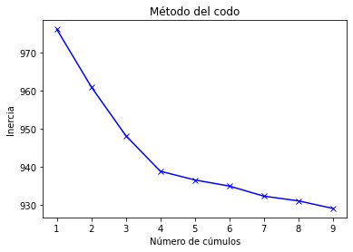

```python
# list(zip(ks,k_inertias))

plt.xlabel("Número de cúmulos")
plt.ylabel("Inercia")
plt.title("Método del codo")
plt.plot(ks, k_inertias, 'bx-');
```

```python
k = 4
model = KMeans(n_clusters=k)
model.fit(tfidf_matrix)
```

```
KMeans(n_clusters=4)
```

```python
data['cluster'] = model.labels_
data
```

|  | Text | cluster |
| --- | --- | --- |
| 0 | a cada etapa do circuito brasileiro banco do b... | 3 |
| 1 | мини-бар — небольшой холодильник с напитками п... | 0 |
| 2 | ломоносов м в «письмо и и шувалову от года» ... | 0 |
| 3 | en les cultivateurs du village se cotisèrent ... | 2 |
| 4 | en el momento de la compra la tarjeta se entre... | 1 |
| 5 | le nombre de clubs engagés étant trop faible p... | 2 |
| 6 | le désastre subi par larmée de metellus permet... | 2 |
| 7 | tama-chan es el hámster mascota de anna sariza... | 1 |
| 8 | ces arbres se plaisent plutôt dans des sols fr... | 0 |
| 9 | o último encontro entre ambas equipes foi em ... | 3 |
| 10 | в январе года в прощальном матче аднана аль-т... | 0 |
| 11 | e portugal finalmente conquistou sua primeira ... | 3 |
| 12 | drača em cirílico драча é uma vila da sérvia l... | 3 |
| 13 | na série drop dead diva april interpreta a mel... | 3 |
| 14 | si f m → n est un difféomorphisme local alors... | 2 |
| 15 | labécédaire de la république et du citoyen par... | 2 |
| 16 | el portador de la bandera en la ceremonia de a... | 1 |
| 17 | в году в санкт-петербурге вышло второе издани... | 0 |
| 18 | los individuos eligen entonces los padres o tu... | 1 |
| 19 | важной стороной ломоносовской методологии явил... | 0 |
| 20 | второе направление призвано сначала привлечь м... | 0 |
| 21 | de modo geral para determinar a pressão de inj... | 3 |
| 22 | термин «онтология» был предложен рудольфом гок... | 0 |
| 23 | la homeostasis del griego ὅμοιος [homoios] «ig... | 1 |
| 24 | tipo de material – material com viscosidade ma... | 3 |
| 25 | a história da suíça propriamente dita começa a... | 3 |
| 26 | l’eurovelo ev également dénommée « la route ... | 2 |
| 27 | tibur era uma das maiores cidades latinas mas ... | 3 |
| 28 | a extinção da dinastia kyburg abriu caminho pa... | 3 |
| 29 | dans le département des landes le ruisseau de ... | 2 |
| ... | ... | ... |
| 970 | após sua vitória sobre jorge masvidal daley as... | 3 |
| 971 | la démarche ne peut aboutir sans quau préalabl... | 2 |
| 972 | расположена в юго-западной части области в км... | 0 |
| 973 | les supporters de lasm clermont auvergne ont r... | 2 |
| 974 | é um mito popular na universidade da califórni... | 3 |
| 975 | марта года вошёл в тренерский штаб цска став... | 0 |
| 976 | en sorolla y benlliure son declarados hijos p... | 1 |
| 977 | евразийская экономическая комиссия еэк — посто... | 0 |
| 978 | a heráldica refere-se simultaneamente à ciênci... | 3 |
| 979 | florimont est une commune française située dan... | 2 |
| 980 | выпуск нелицензированных копий установок «бофо... | 0 |
| 981 | lugar de realengo de españa provincia y azobis... | 3 |
| 982 | wilson d e reeder d m eds mammal species of t... | 0 |
| 983 | novidades como o corps de logis que toma uma g... | 3 |
| 984 | según el censo de [] había personas residien... | 1 |
| 985 | la mayor parte de su obra está redactada en la... | 1 |
| 986 | "pilot" é o primeiro episódio da série de tele... | 3 |
| 987 | apertura del camino real rn ahora la avenue ... | 1 |
| 988 | em de junho apenas uma semana após ser libera... | 3 |
| 989 | в - учился в школе в центре москвы закончил ... | 0 |
| 990 | tendo descrito a vitória de camilo contra os v... | 3 |
| 991 | "una acción contrarrevolucionaria es cualquier... | 1 |
| 992 | la composición fue anotada en el catálogo pers... | 1 |
| 993 | el investigador ha recibido varios reconocimie... | 1 |
| 994 | pueden funcionar como complemento directo unid... | 0 |
| 995 | el departamento cuenta con varios canales de t... | 1 |
| 996 | farrington d p b implications of biological fi... | 0 |
| 997 | клевцов в герой несуществующей державы в клев... | 0 |
| 998 | le mars tag heuer annonce à l’occasion du ba... | 2 |
| 999 | gillison douglas australia in the war of – se... | 0 |

1000 rows × 2 columns

```python
nbrs = NearestNeighbors(n_neighbors=3, metric='euclidean').fit(tfidf_matrix.values)

clust_cnt = data['cluster'].value_counts()
clust_cnt_pct = data['cluster'].value_counts(normalize=True)

centroids = model.cluster_centers_

terms = tfidf_vect.get_feature_names()
order_centroids = centroids.argsort()[:, ::-1]

for i in range(k):
    print(f"Cluster # {i}")
    print(f"Tiene {clust_cnt[i]} registros ({clust_cnt_pct[i]:.2%} de los datos)")
    print()

    print("TÉRMINOS MÁS REPRESENTATIVOS")
    for ind in order_centroids[i][:20]:
        print(terms[ind], end=" ")
    print()
    print()

    print(f"DOCUMENTOS MÁS REPRESENTATIVOS")
    for vecino in data.iloc[nbrs.kneighbors([centroides[i]])[1][0]].Text.values:
        print(f" *** {vecino}")
        print()

    print()
    print("********************************************")
    print()
```

```
Cluster # 0
Tiene 282 registros (28.20% de los datos)

TÉRMINOS MÁS REPRESENTATIVOS
на года по году для не из был от его что за церкви также ломоносова ломоносов комиссии как он the

DOCUMENTOS MÁS REPRESENTATIVOS
 *** в  году овчинников окончательно вытеснил из основы «локомотива» хасанби биджиева пропустив всего  мяч в  матчах и как следствие получил приглашение в только что образованную сборную россии на её первый в истории матч на стадионе «локомотив» против сборной мексики однако на поле так и не вышел н…

 *** с октября  года начала действия договора по апрель  года товарооборот между странами увеличился на  экспорт вырос на  импорт — на

 *** в апреле  года ломоносов за дерзкое поведение при академических распрях между «русской» и «немецкой» партиями был заключён под стражу на  месяцев только  января  года сенат заслушав доклад следственной комиссии постановил «оного адъюнкта ломоносова для его довольного обучения от наказания освоб…



Cluster # 1
Tiene 251 registros (25.10% de los datos)

TÉRMINOS MÁS REPRESENTATIVOS
de el la en del los su que es una con se por un las al para fue como más

DOCUMENTOS MÁS REPRESENTATIVOS
 *** cresta del club se deriva de la de los municipio de sutton la diferencia es que unidos seleccionado sólo las partes de la cresta que representan el sutton y cheam en oposición a las partes de cresta del municipio que significa beddington wallington y carshalton los discos de oro y de plata en e…

 *** reclutado en el verano de  comenzó su carrera en el equipo de bachillerato de la universidad popular autónoma del estado de puebla upaep para después de  años ingresar en la misma institución a la carrera de ciencias de la comunicación upaep es una universidad mexicana con un equipo de balonces…

 *** en septiembre consigue su mejor victoria como profesional en la vuelta a españa al ganar en la mítica cima del angliru tras meterse en la fuga buena del día de  corredores y en los que había ciclistas de la talla de paolo tiralongo serge pauwels o david arroyo elissonde lanzó un ataque en el al…



Cluster # 2
Tiene 227 registros (22.70% de los datos)

TÉRMINOS MÁS REPRESENTATIVOS
de le et la les du des en est dans une par au il un avec pour qui france sur

DOCUMENTOS MÁS REPRESENTATIVOS
 *** le rugby est en france le deuxième sport collectif le plus populaire même si dans certaines régions il fait jeu égal avec le football les régions du sud-ouest sont celles où ce sport est le plus pratiqué et suivi tandis quau nord de lhexagone il est beaucoup moins populaire hormis en île-de-fra…

 *** le rugby se développe particulièrement en aquitaine sous linfluence des échanges commerciaux avec langleterre friande des vins de bordeaux les négociants en vin britanniques formant dans cette région une colonie vinicole et rugbystique le rugby sy diffuse par la suite par larrivée détudiants et…

 *** dans ce contexte de guerre ethnique et précisément au moment où lagitation en faveur de louis riel samplifie ces nominations ne sont pas très heureuses quand mgr taché obtient un sursis dun mois pour permettre aux avocats de louis riel de porter sa cause en appel au conseil privé des émeutes co…



Cluster # 3
Tiene 240 registros (24.00% de los datos)

TÉRMINOS MÁS REPRESENTATIVOS
de em do da uma no que um com os foi na por para se como as dos mais sua

DOCUMENTOS MÁS REPRESENTATIVOS
 *** o râguebi foi apresentado aos francesas na cidade de le havre por mercadores ingleses em  e se espalhou pelo resto do país apesar de ter sido a primeira vez introduzido no norte foi no sul no meio da população rural e pobre trabalhadora dos vinhedos que o râguebi se popularizou na frança o prim…

 *** o tufão melor formou-se de uma área de perturbações meteorológicas que persistia a cerca de  km a sul do atol de kwajalein ilhas marshall começou a mostrar sinais de organização em  de setembro inicialmente a perturbação estava dotada de áreas fragmentadas de convecção profunda que estavam come…

 *** eleito bispo de coutances em  de setembro de  legado papal na inglaterra em  transferido para a sé de pavia em  de outubro de  legado papal dos papas nicolau v e calisto iii na germânia intervindo nas dietas de ratisbona em abril de  e frankfurt em outubro de  sua principal incumbência era de p…
```

```python
clusters = {0: 'Ruso',
            1: "Español",
            2: 'Francés',
            3: 'Portugués'}

data['nombres_clusters'] = data['cluster'].apply(lambda val: clusters[val])
data.sample(2)
```

|  | Text | cluster | nombres_clusters |
| --- | --- | --- | --- |
| 816 | гео́ргий васи́льевич за́йченко июня славянс... | 0 | Ruso |
| 208 | fundada em olinda é a mais antiga entre as ci... | 3 | Portugués |

```python
df_centroids = pd.DataFrame(centroids)
df_centroids['cluster'] = clusters.values()
df_centroids
```

|  | 0 | 1 | 2 | 3 | 4 | 5 | 6 | 7 | 8 | 9 | ... | 20448 | 20449 | 20450 | 20451 | 20452 | 20453 | 20454 | 20455 | 20456 | cluster |
| --- | --- | --- | --- | --- | --- | --- | --- | --- | --- | --- | --- | --- | --- | --- | --- | --- | --- | --- | --- | --- | --- |
| 0 | 2.389265e-03 | 5.421011e-20 | 0.000000e+00 | 4.065758e-20 | 8.131516e-20 | -2.710505e-20 | -1.626303e-19 | -8.131516e-20 | 8.131516e-20 | 2.439455e-19 | ... | 7.546527e-04 | -1.084202e-19 | 1.897354e-19 | 1.897354e-19 | -1.626303e-19 | -8.131516e-20 | 2.710505e-20 | 2.168404e-19 | 2.168404e-19 | Ruso |
| 1 | -9.757820e-19 | 4.065758e-20 | -2.710505e-20 | 3.411909e-04 | 8.131516e-20 | -2.710505e-20 | 4.947761e-04 | -9.486769e-20 | 3.262654e-04 | 7.837156e-04 | ... | 2.168404e-19 | 4.993962e-04 | 1.626303e-19 | 1.626303e-19 | -1.355253e-19 | -8.131516e-20 | 8.868720e-04 | 5.043687e-04 | 5.043687e-04 | Español |
| 2 | 5.709472e-04 | 1.355253e-20 | -5.421011e-20 | 2.710505e-20 | 6.776264e-20 | 9.099553e-04 | -1.626303e-19 | -9.486769e-20 | 1.355253e-20 | 2.439455e-19 | ... | 1.355253e-19 | 0.000000e+00 | 7.900961e-04 | 7.900961e-04 | 6.513262e-04 | -8.131516e-20 | 0.000000e+00 | 1.626303e-19 | 1.626303e-19 | Francés |
| 3 | -7.589415e-19 | 4.015270e-04 | 2.555090e-04 | 4.065758e-20 | 2.729548e-04 | -5.421011e-20 | -1.626303e-19 | 4.454947e-04 | 4.065758e-20 | 2.439455e-19 | ... | 1.897354e-19 | -2.710505e-20 | 1.626303e-19 | 1.626303e-19 | -1.355253e-19 | 5.559149e-04 | 0.000000e+00 | 1.897354e-19 | 1.897354e-19 | Portugués |

4 rows × 20458 columns

```python
# ! pip install plotly
from sklearn.decomposition import PCA
import plotly.graph_objs as go
from plotly.offline import iplot
```

```python
pca = PCA(n_components=2)

result = pca.fit_transform(tfidf_matrix)
result = pd.DataFrame(result)
result.columns = ['X', 'Y']
result['cluster'] = data.nombres_clusters.values
result['texto'] = data.Text.apply(lambda val: val[:140])

colorsIdx = {'Ruso': 'blue',
             'Español': 'yellow',
             'Portugués': 'green',
             'Francés': 'red'}

result['colores'] = result['cluster'].map(colorsIdx)


result.head()
```

|  | X | Y | cluster | texto | colores |
| --- | --- | --- | --- | --- | --- |
| 0 | -0.091921 | -0.062549 | Portugués | a cada etapa do circuito brasileiro banco do b... | green |
| 1 | -0.129491 | 0.015921 | Ruso | мини-бар — небольшой холодильник с напитками п... | blue |
| 2 | -0.135561 | 0.016843 | Ruso | ломоносов м в «письмо и и шувалову от года» ... | blue |
| 3 | 0.104762 | 0.212234 | Francés | en les cultivateurs du village se cotisèrent ... | red |
| 4 | 0.193633 | -0.095641 | Español | en el momento de la compra la tarjeta se entre... | yellow |

```python
trace = go.Scatter(x=result['X'].values,
                   y=result['Y'].values,
                   text=result['texto'].values,
                   mode='markers',
                   marker=dict(color=result['colores'].values))

layout = go.Layout(title="PCA")

fig = go.Figure(data=trace, layout=layout)
iplot(fig)
```

[interactive chart not shown]

# 👩‍💻 Manos a la obra

**Paso 3:** Hacer predicciones

```python
nuevo = ["El vecino de la profesora puso música esta tarde",
         "Bom dia pessoal, o Brasil é o melhor pais do mundo",
         "La serie Game of Thrones ganó en los TV Awards of Los Angeles",
         "Bom dia meus caros amigos, buenos días mis queridos amigos"]
nuevo_trans = tfidf_vect.transform(nuevo)
[clusters[i] for i in model.predict(nuevo_trans)]
```

```
['Español', 'Portugués', 'Español', 'Ruso']
```

# 🙁 ¿Qué puede salir mal?

Desventajas de K-means

• Se tiene que escoger $K$ con antelación (más de eso adelante)

• Es intensivo computacionalmente

• Cada observación pertenece a un sólo cúmulo

• Sensible a las observaciones atípicas

• No puede modelar relaciones complejas

# 🙁 ¿Qué puede salir mal?

Cuando NO usar K-means

[figure not shown]

# 🙁 ¿Qué puede salir mal?

Cuando NO usar K-means

[figure not shown]

# 🙁 ¿Qué puede salir mal?

Cuando NO usar K-means

[figure not shown]

# 🤓 Recapitulando

[figure not shown]

• Los modelos de agrupación son técnicas no supervisadas de Machine Learning que buscan extraer la estructura de los datos al juntar las observaciones similares.

• K-means es el modelo de agrupación más usado

• El algoritmo es iterativo y reasigna los centroides hasta cuando ya no haya cambio en los grupos

• Como todo modelo, es importante hacer una buena selección de variables dependientes y usar conocimento del tema para evaluar e interpretar el modelo.

• Hay que considerar las limitaciones del modelo a la hora de escoger trabajar o no con él.

# 🤔 Más algoritmos de agrupación

[figure not shown]

Lectura adicional: [Documentación](https://scikit-learn.org/stable/modules/clustering.html), [Más ejemplos](http://brandonrose.org/clustering?ref=dzone)

# ¡Tiempo de taller!

[figure not shown]

**Taller #8:** K-Means

[figure not shown]

### Próxima clase: Modelado de temas